# 07 — Walk-Forward Validation & Temporal Stability

### 2.3 Rolling Forecasts for EGARCH (IBEX & SPX)

- `iteration`, `train_start`, `train_end`, `test_end`
- `model = "EGARCH"`
- `index = "IBEX"` / `"SPX"`
- `mae`, `rmse`

This allows direct comparison of volatility forecast quality across time and across indices.

```python
# ============================================
# STEP 2 — WALK-FORWARD (ARIMA) + EGARCH
# ============================================

import warnings
warnings.filterwarnings("ignore")

import numpy as np
import pandas as pd
import statsmodels.api as sm
from arch import arch_model
from math import sqrt
from sklearn.metrics import mean_absolute_error, mean_squared_error

print("STEP 2 — Starting efficient forecasting pipeline...\n")

# =========================================================
# 2.1 LOAD RETURNS (from Step 1)
# =========================================================

df_ret = df_ret.copy()     # viene del Step 1
returns_ibex = df_ret["IBEX"].astype(float).dropna()
returns_spx  = df_ret["SPX"].astype(float).dropna()

print("Returns loaded:", df_ret.shape)
display(df_ret.head())

print("IBEX series length:", len(returns_ibex))
print("SPX series length:", len(returns_spx))


# =========================================================
# 2.2 CONFIGURATION
# =========================================================

WINDOW_TRAIN = 2520     # 10 años de datos
WINDOW_TEST  = 63       # 3 meses
STEP_SIZE    = WINDOW_TEST

print(f"\nARIMA walk-forward config → train={WINDOW_TRAIN}, test={WINDOW_TEST}, step={STEP_SIZE}")


# =========================================================
# 2.3 Metrics helper
# =========================================================

def compute_metrics(y_true, y_pred):
    mae = mean_absolute_error(y_true, y_pred)
    rmse = sqrt(mean_squared_error(y_true, y_pred))
    return mae, rmse


# =========================================================
# 2.4 WALK-FORWARD ARIMA
# =========================================================

def walk_forward_arima(series, name):

    results = []
    total_steps = (len(series) - WINDOW_TRAIN) // STEP_SIZE
    print(f"\nRunning ARIMA walk-forward — {name} ({total_steps} iterations)...")

    for i in range(total_steps):

        start_train = i * STEP_SIZE
        end_train   = start_train + WINDOW_TRAIN
        end_test    = end_train + WINDOW_TEST

        train = series.iloc[start_train:end_train]
        test  = series.iloc[end_train:end_test]

        if len(test) == 0:
            break

        try:
            model = sm.tsa.ARIMA(train, order=(1,0,1))
            fitted = model.fit()
            forecast = fitted.forecast(steps=len(test))

            mae, rmse = compute_metrics(test, forecast)

            results.append({
                "iteration": i+1,
                "model": "ARIMA",
                "index": name,
                "train_start": train.index[0],
                "train_end": train.index[-1],
                "test_end": test.index[-1],
                "mae": mae,
                "rmse": rmse
            })

        except Exception as e:
            print(f"ARIMA iteration {i+1} failed for {name}: {e}")

    df = pd.DataFrame(results)
    print(f"Completed ARIMA walk-forward — {name}")
    return df


# =========================================================
# 2.5 EGARCH — One Fit + Full σ_t Extraction (FAST)
# =========================================================

def egarch_onefit_forecast(series, name):
    """
    Entrena un EGARCH una sola vez y devuelve TODA la serie σ_t.
    No forecast 1-step: usamos conditional_volatility.
    """

    print(f"\nFitting EGARCH(1,1) model — {name}...")

    model = arch_model(series * 100, vol="EGARCH", p=1, o=1, q=1, dist="t")
    fitted = model.fit(disp="off")

    print(f"Extracting conditional volatility series — {name}...")

    sigma = fitted.conditional_volatility / 100
    sigma.index = series.index
    sigma.name = f"EGARCH_vol_{name}"

    return sigma


# =========================================================
# 2.6 EXECUTE FORECASTING
# =========================================================

# ARIMA walk-forward
arima_ibex = walk_forward_arima(returns_ibex, "IBEX")
arima_spx  = walk_forward_arima(returns_spx,  "SPX")

# EGARCH fast
egarch_vol_ibex = egarch_onefit_forecast(returns_ibex, "IBEX")
egarch_vol_spx  = egarch_onefit_forecast(returns_spx,  "SPX")

print("\nEGARCH volatility extraction complete.")


# =========================================================
# 2.7 COMBINE RESULTS
# =========================================================

walkforward_results = pd.concat([arima_ibex, arima_spx]).reset_index(drop=True)

egarch_vol_df = pd.DataFrame({
    "Date": egarch_vol_ibex.index,
    "Vol_IBEX_EGARCH": egarch_vol_ibex.values,
    "Vol_SPX_EGARCH":  egarch_vol_spx.values
}).set_index("Date")

print("\nSTEP 2 Completed Successfully.")
display(walkforward_results.head())
display(egarch_vol_df.head())
```

```
STEP 2 — Starting efficient forecasting pipeline...

Returns loaded: (6421, 2)
```

| Date | IBEX | SPX |
| --- | --- | --- |
| 2000-01-04 | -0.035364 | -0.039099 |
| 2000-01-05 | -0.031131 | 0.001920 |
| 2000-01-07 | 0.021790 | 0.027685 |
| 2000-01-10 | 0.006366 | 0.011128 |
| 2000-01-11 | -0.014505 | -0.013149 |

```
IBEX series length: 6421
SPX series length: 6421

ARIMA walk-forward config → train=2520, test=63, step=63

Running ARIMA walk-forward — IBEX (61 iterations)...
Completed ARIMA walk-forward — IBEX

Running ARIMA walk-forward — SPX (61 iterations)...
Completed ARIMA walk-forward — SPX

Fitting EGARCH(1,1) model — IBEX...
Extracting conditional volatility series — IBEX...

Fitting EGARCH(1,1) model — SPX...
Extracting conditional volatility series — SPX...

EGARCH volatility extraction complete.

STEP 2 Completed Successfully.
```

|  | iteration | model | index | train_start | train_end | test_end | mae | rmse |
| --- | --- | --- | --- | --- | --- | --- | --- | --- |
| 0 | 1 | ARIMA | IBEX | 2000-01-04 | 2010-04-08 | 2010-07-08 | 0.020818 | 0.029493 |
| 1 | 2 | ARIMA | IBEX | 2000-04-05 | 2010-07-08 | 2010-10-06 | 0.010131 | 0.012972 |
| 2 | 3 | ARIMA | IBEX | 2000-07-10 | 2010-10-06 | 2011-01-06 | 0.010031 | 0.013308 |
| 3 | 4 | ARIMA | IBEX | 2000-10-06 | 2011-01-06 | 2011-04-07 | 0.009363 | 0.013224 |
| 4 | 5 | ARIMA | IBEX | 2001-01-16 | 2011-04-07 | 2011-07-11 | 0.009765 | 0.012311 |

| Date | Vol_IBEX_EGARCH | Vol_SPX_EGARCH |
| --- | --- | --- |
| 2000-01-04 | 0.017834 | 0.016499 |
| 2000-01-05 | 0.021336 | 0.022245 |
| 2000-01-07 | 0.023881 | 0.020620 |
| 2000-01-10 | 0.022599 | 0.018888 |
| 2000-01-11 | 0.021247 | 0.017475 |

## STEP 3 Out-of-Sample Error Evaluation (MAE & RMSE)

This step evaluates the **forecasting accuracy** of all walk-forward models (ARIMA and EGARCH) and examines how their performance evolves over time.  
We analyse those outputs to understand how forecasts behave across market regimes and across indices. It is important to clarify that both are usefull here because MAE penalises all errors linearly, while RMSE gives more weight to bigger mistakes.

### **1. Consolidation of Walk-Forward Errors**

All rolling forecasts are loaded from the walk-forward results file and merged so that each row represents:

- one walk-forward iteration
- one training window (10 years)
- one test window (3 months)
- one model (ARIMA or EGARCH)
- one index (IBEX or SPX)
- the resulting MAE and RMSE

### **2. Global Performance Statistics**

For each model–index pair, the notebook computes:

- **Mean MAE/RMSE** → average forecast error
- **Median MAE/RMSE** → typical forecast error
- **Standard deviation** → variability in error
- **95th percentile** → magnitude of large error spikes

These statistics highlight important differences:

- ARIMA generally delivers lower and more stable errors.
- SPX is easier to forecast than IBEX.
- EGARCH exhibits higher error variability due to volatility shocks.

### **3. Rolling Stability Analysis (Smoothed Errors)**

To analyse how accuracy evolves through time, the notebook smooths the error series using rolling windows:

- `mae_roll` = rolling mean MAE
- `rmse_roll` = rolling mean RMSE

A 4-iteration window (≈ one year) reduces noise and highlights:

- slow accuracy deterioration
- volatility-related changes
- decade-by-decade differences
- model breakdowns during crisis episodes (2008, COVID-19, etc.)

Rolling stability is important because models may look fine on aggregate metrics but still fail in specific market regimes.

### **4. Detection of High-Error Regimes**

The notebook flags periods where rmse_roll > 75th percentile of RMSE because identifying these windows helps recognise when and why a model becomes unreliable, and normally these high-error regimes typically correspond to:

- structural breaks
- volatility explosions
- trend reversals
- crisis conditions

```python
# STEP 3 — OUT-OF-SAMPLE ERROR EVALUATION (MAE, RMSE)

import pandas as pd
import numpy as np
from pathlib import Path

# 3.0 Reconstruct project paths
PROJECT_ROOT = Path.home() / "projects" / "ibex-sp500-forecasting"
DATA_PATH    = PROJECT_ROOT / "data"
RESULTS_PATH = DATA_PATH / "results"
FEATURES_PATH = DATA_PATH / "features"
MODELS_PATH  = DATA_PATH / "models"

print("Paths loaded:")
for p in [DATA_PATH, RESULTS_PATH, MODELS_PATH, FEATURES_PATH]:
    print("—", p)

# 3.1 Load walk-forward raw results
wf_path = RESULTS_PATH / "walkforward_stability.csv"

print("\nLoading walk-forward results...")
if not wf_path.exists():
    raise FileNotFoundError(f"ERROR: walkforward_stability.csv not found → {wf_path}")

walkforward_results = pd.read_csv(
    wf_path,
    parse_dates=["train_start","train_end","test_end"]
)

print("Loaded:", walkforward_results.shape)

# Required columns
required_cols = {
    "iteration","model","index","mae","rmse",
    "train_start","train_end","test_end"
}
missing = required_cols - set(walkforward_results.columns)
if missing:
    raise ValueError(f"Missing required columns: {missing}")

walkforward_results = walkforward_results.sort_values(
    ["model","index","iteration"]
).reset_index(drop=True)

print("\nColumns OK")

# 3.2 Summary statistics (by model & index)
summary_stats = (
    walkforward_results
    .groupby(["model","index"], as_index=False)
    .agg(
        n_iters   =("iteration","count"),
        mae_mean  =("mae","mean"),
        mae_median=("mae","median"),
        mae_std   =("mae","std"),
        mae_p95   =("mae", lambda s: np.nanpercentile(s,95)),
        rmse_mean =("rmse","mean"),
        rmse_median=("rmse","median"),
        rmse_std  =("rmse","std"),
        rmse_p95  =("rmse", lambda s: np.nanpercentile(s,95)),
    )
)

print("\n Summary of MAE / RMSE by model & index:")
display(summary_stats)

# 3.3 Rolling stability (smooth errors over K iterations)
ROLL_K = 4   # ~1 year if 3-month blocks

def add_rolling(df):
    df = df.sort_values("iteration").copy()
    df["mae_roll"]  = df["mae"].rolling(ROLL_K, min_periods=1).mean()
    df["rmse_roll"] = df["rmse"].rolling(ROLL_K, min_periods=1).mean()
    return df

rolling_errors = (
    walkforward_results
    .groupby(["model","index"], group_keys=False)
    .apply(add_rolling)
    .reset_index(drop=True)
)

print(f"\n Rolling stability added (window={ROLL_K} iterations).")
display(rolling_errors.head())

# 3.4 Degradation flags (RMSE regime check)
thresholds = rolling_errors.groupby(
    ["model","index"]
)["rmse_roll"].transform(lambda s: np.nanpercentile(s, 75))

rolling_errors["high_error_regime"] = (
    rolling_errors["rmse_roll"] > thresholds
).astype(int)

print("\nHigh-error regimes flagged (rmse_roll > 75th percentile).")

# 3.5 Export results for Power BI
RESULTS_PATH.mkdir(parents=True, exist_ok=True)

errors_file  = RESULTS_PATH / "walkforward_errors.csv"
summary_file = RESULTS_PATH / "walkforward_errors_summary.csv"

rolling_errors.to_csv(errors_file, index=False)
summary_stats.to_csv(summary_file, index=False)

print("\n Exported for Power BI:")
print("•", errors_file)
print("•", summary_file)

# 3.6 Quick digest (text summary)
def quick_digest(df):
    lines = []
    for (model, idx), g in df.groupby(["model","index"]):
        lines.append(
            f"{model}-{idx}: "
            f"MAE mean={g['mae'].mean():.5f}, RMSE mean={g['rmse'].mean():.5f} | "
            f"MAE p95={np.nanpercentile(g['mae'],95):.5f}, "
            f"RMSE p95={np.nanpercentile(g['rmse'],95):.5f}"
        )
    return "\n".join(lines)

print("\nDIGEST (quick summary):")
print(quick_digest(walkforward_results))
```

```
Paths loaded:
— /home/apalo/projects/ibex-sp500-forecasting/data
— /home/apalo/projects/ibex-sp500-forecasting/data/results
— /home/apalo/projects/ibex-sp500-forecasting/data/models
— /home/apalo/projects/ibex-sp500-forecasting/data/features

Loading walk-forward results...
Loaded: (264, 8)

Columns OK

 Summary of MAE / RMSE by model & index:
```

|  | model | index | n_iters | mae_mean | mae_median | mae_std | mae_p95 | rmse_mean | rmse_median | rmse_std | rmse_p95 |
| --- | --- | --- | --- | --- | --- | --- | --- | --- | --- | --- | --- |
| 0 | ARIMA | IBEX | 66 | 0.009219 | 0.008040 | 0.003638 | 0.016273 | 0.012286 | 0.010283 | 0.005250 | 0.021702 |
| 1 | ARIMA | SPX | 66 | 0.007022 | 0.006107 | 0.003642 | 0.012693 | 0.009546 | 0.008331 | 0.005119 | 0.017035 |
| 2 | EGARCH | IBEX | 66 | 0.014080 | 0.012564 | 0.005064 | 0.023808 | 0.017523 | 0.015232 | 0.006905 | 0.030657 |
| 3 | EGARCH | SPX | 66 | 0.010316 | 0.008829 | 0.004932 | 0.019401 | 0.013216 | 0.011631 | 0.006798 | 0.025110 |

```
 Rolling stability added (window=4 iterations).
```

|  | iteration | train_start | train_end | test_end | model | index | mae | rmse | mae_roll | rmse_roll |
| --- | --- | --- | --- | --- | --- | --- | --- | --- | --- | --- |
| 0 | 1 | 2000-01-04 | 2009-08-31 | 2009-11-26 | ARIMA | IBEX | 0.010187 | 0.012472 | 0.010187 | 0.012472 |
| 1 | 2 | 2000-03-31 | 2009-11-26 | 2010-02-23 | ARIMA | IBEX | 0.010172 | 0.013996 | 0.010180 | 0.013234 |
| 2 | 3 | 2000-06-28 | 2010-02-23 | 2010-05-21 | ARIMA | IBEX | 0.016421 | 0.025869 | 0.012260 | 0.017446 |
| 3 | 4 | 2000-09-25 | 2010-05-21 | 2010-08-18 | ARIMA | IBEX | 0.013827 | 0.018434 | 0.012652 | 0.017693 |
| 4 | 5 | 2000-12-21 | 2010-08-18 | 2010-11-15 | ARIMA | IBEX | 0.008806 | 0.011208 | 0.012307 | 0.017377 |

```
High-error regimes flagged (rmse_roll > 75th percentile).

 Exported for Power BI:
• /home/apalo/projects/ibex-sp500-forecasting/data/results/walkforward_errors.csv
• /home/apalo/projects/ibex-sp500-forecasting/data/results/walkforward_errors_summary.csv

DIGEST (quick summary):
ARIMA-IBEX: MAE mean=0.00922, RMSE mean=0.01229 | MAE p95=0.01627, RMSE p95=0.02170
ARIMA-SPX: MAE mean=0.00702, RMSE mean=0.00955 | MAE p95=0.01269, RMSE p95=0.01704
EGARCH-IBEX: MAE mean=0.01408, RMSE mean=0.01752 | MAE p95=0.02381, RMSE p95=0.03066
EGARCH-SPX: MAE mean=0.01032, RMSE mean=0.01322 | MAE p95=0.01940, RMSE p95=0.02511
```

## STEP 4 Dynamic VaR Coverage Analysis (Walk-Forward Exceedance Tests)

This step evaluates whether the EGARCH model provides accurate and stable estimates of tail risk over time by running a walk-forward validation of **VaR 95% coverage**. The notebook measures how well the model calibrates extreme risk across all rolling windows.

### Rolling VaR Exceedance Rate

For each walk-forward window, we compute the exceedance indicator:

$$ I_t = \begin{cases} 1 & \text{if } r_t < \text{VaR}_{\alpha,t}, \\ 0 & \text{otherwise} \end{cases} $$

The rolling (k-window) coverage ratio is:

$$ \hat{p}_{t}^{(k)} = \frac{1}{k} \sum_{i=t-k+1}^{t} I_i $$

### What This Step Does

For every walk-forward window:

1. An EGARCH model is re-estimated on the training period.
2. One-day-ahead volatility forecasts and VaR95 predictions are produced.
3. The number of exceedances (days where return < VaR) is counted.
4. The observed coverage rate is compared against the ideal 5%.

The notebook also computes rolling coverage to evaluate the *temporal stability* of the risk forecasts and detect:

- periods of risk underestimation (too many exceedances),
- periods of risk overestimation (too few exceedances),
- shifts in the return–volatility relationship across market regimes.

### General Findings

These results indicate that the EGARCH model adapts reasonably well to changing volatility regimes and provides reliable short-horizon tail-risk estimates.

### Conclusion

```python
# STEP 4 — DYNAMIC VAR COVERAGE (ROLLING EXCEEDANCE TESTS)

import pandas as pd
import numpy as np
from pathlib import Path
from scipy.stats import norm


# 4.0 Reconstruct paths if Step 1 is not loaded
PROJECT_ROOT = Path.home() / "projects" / "ibex-sp500-forecasting"
DATA_PATH    = PROJECT_ROOT / "data"
RESULTS_PATH = DATA_PATH / "results"
FEATURES_PATH = DATA_PATH / "features"
MODELS_PATH  = DATA_PATH / "models"

print("Paths loaded:")
for p in [DATA_PATH, RESULTS_PATH, MODELS_PATH, FEATURES_PATH]:
    print("—", p)

# 4.1 Load walk-forward stability dataset (Step 2 output)
wf_file = RESULTS_PATH / "walkforward_stability.csv"

print("\nLoading walk-forward results for VaR coverage...")
if not wf_file.exists():
    raise FileNotFoundError(f"walkforward_stability.csv not found → {wf_file}")

wf = pd.read_csv(wf_file, parse_dates=["train_start","train_end","test_end"])
print("Loaded:", wf.shape)

# 4.2 Choose VaR confidence level
ALPHA = 0.05      # VaR95 (5% tail)
Z = norm.ppf(ALPHA)   # ≈ -1.645

print(f"\nVaR confidence level: 95% | z = {Z:.3f}")

# 4.3 Load returns for reconstruction of true exceedances
returns_file = FEATURES_PATH / "returns.csv"
if not returns_file.exists():
    raise FileNotFoundError(f"returns.csv not found → {returns_file}")

returns = pd.read_csv(returns_file, index_col=0, parse_dates=True)
returns.columns = returns.columns.str.replace("_ret","")

print("Returns loaded:", returns.columns.tolist())

# 4.4 Function to reconstruct 1-step-ahead VaR for each WF iteration
from arch import arch_model

def compute_var_exceedances(series, wf_iter, index_name):
    """
    Reconstructs 1-step VaR using EGARCH in daily walk-forward mode
    for each iteration. Counts exceedances.
    """
    start_train = wf_iter["train_start"]
    end_train   = wf_iter["train_end"]
    end_test    = wf_iter["test_end"]

    # extract training window and test window
    train = series.loc[start_train:end_train]
    test  = series.loc[end_train:end_test]

    if len(test) == 0:
        return None

    rolling = train.copy()
    var_list = []
    true_list = []

    # daily rolling 1-step EGARCH forecast
    for t in range(len(test)):
        model = arch_model(rolling * 100, vol="EGARCH", p=1, o=1, q=1, dist="t")
        fitted = model.fit(disp="off")

        # 1-step volatility forecast
        f = fitted.forecast(horizon=1)
        sigma = np.sqrt(f.variance.values[-1, 0]) / 100   # scale back

        var_t1 = Z * sigma  # mean assumed = 0
        var_list.append(var_t1)

        real = test.iloc[t]
        true_list.append(real)

        # expand rolling window with realized value
        rolling = pd.concat([rolling, pd.Series(real, index=[test.index[t]])])

    var_array = np.array(var_list)
    true_array = np.array(true_list)

    exceedances = (true_array < var_array).sum()

    return {
        "iteration": int(wf_iter["iteration"]),
        "index": index_name,
        "n_test": len(test),
        "var_exceedances": exceedances,
        "coverage_rate": exceedances / len(test)
    }

# 4.5 Apply VaR coverage computation per index
print("\nComputing rolling VaR coverage...")

results_var = []

for idx_name in ["IBEX", "SPX"]:

    sub = wf[wf["model"] == "EGARCH"]
    sub = sub[sub["index"] == idx_name]

    series = returns[idx_name].dropna()

    for _, row in sub.iterrows():
        out = compute_var_exceedances(series, row, idx_name)
        if out is not None:
            results_var.append(out)

var_df = pd.DataFrame(results_var).sort_values(["index","iteration"])

print("VaR coverage computed:", var_df.shape)
display(var_df.head())

# 4.6 Rolling expected vs observed coverage
ROLL_K = 4  # same as Step 3

var_df["coverage_roll"] = (
    var_df.groupby("index")["coverage_rate"]
    .rolling(ROLL_K, min_periods=1)
    .mean()
    .reset_index(level=0, drop=True)
)

# theoretical coverage = ALPHA = 0.05
var_df["expected_coverage"] = ALPHA

# deviation from expected coverage
var_df["coverage_gap"] = var_df["coverage_roll"] - ALPHA

print("\nRolling coverage added:")
display(var_df.head())

# 4.7 Export to Power BI
output_var = RESULTS_PATH / "walkforward_var_coverage.csv"
var_df.to_csv(output_var, index=False)

print("\nExported VaR coverage →", output_var)
```

```
Paths loaded:
— /home/apalo/projects/ibex-sp500-forecasting/data
— /home/apalo/projects/ibex-sp500-forecasting/data/results
— /home/apalo/projects/ibex-sp500-forecasting/data/models
— /home/apalo/projects/ibex-sp500-forecasting/data/features

Loading walk-forward results for VaR coverage...
Loaded: (264, 8)

VaR confidence level: 95% | z = -1.645
Returns loaded: ['IBEX', 'SPX']

Computing rolling VaR coverage...
VaR coverage computed: (132, 5)
```

|  | iteration | index | n_test | var_exceedances | coverage_rate |
| --- | --- | --- | --- | --- | --- |
| 0 | 1 | IBEX | 62 | 2 | 0.032258 |
| 1 | 2 | IBEX | 57 | 5 | 0.087719 |
| 2 | 3 | IBEX | 62 | 5 | 0.080645 |
| 3 | 4 | IBEX | 62 | 4 | 0.064516 |
| 4 | 5 | IBEX | 63 | 3 | 0.047619 |

```
Rolling coverage added:
```

|  | iteration | index | n_test | var_exceedances | coverage_rate | coverage_roll | expected_coverage | coverage_gap |
| --- | --- | --- | --- | --- | --- | --- | --- | --- |
| 0 | 1 | IBEX | 62 | 2 | 0.032258 | 0.032258 | 0.05 | -0.017742 |
| 1 | 2 | IBEX | 57 | 5 | 0.087719 | 0.059989 | 0.05 | 0.009989 |
| 2 | 3 | IBEX | 62 | 5 | 0.080645 | 0.066874 | 0.05 | 0.016874 |
| 3 | 4 | IBEX | 62 | 4 | 0.064516 | 0.066285 | 0.05 | 0.016285 |
| 4 | 5 | IBEX | 63 | 3 | 0.047619 | 0.070125 | 0.05 | 0.020125 |

```
Exported VaR coverage → /home/apalo/projects/ibex-sp500-forecasting/data/results/walkforward_var_coverage.csv
```

## STEP 5 Stability Tests (CUSUM & CUSUMSQ)

This step evaluates whether the forecasting models (ARIMA and EGARCH) remain structurally stable over time, using the walk-forward errors computed previously. The focus here is on detecting drifts, persistent deterioration, or regime breaks in model performance.

To do this, two classical econometric tools are applied:

- **CUSUM**: cumulative sum of standardised deviations, sensitive to shifts in the mean of the error process.
- **CUSUMSQ**: cumulative sum of squared standardised deviations, sensitive to shifts in the variance of the errors.

They are applied to **RMSE across walk-forward iterations, which is directly analogous to forecasting stability.

### What the CUSUM results show

- **ARIMA–IBEX**: final CUSUM ≈ 0
- **ARIMA–SPX** : final CUSUM ≈ 0
- **EGARCH–IBEX**: final CUSUM ≈ 0
- **EGARCH–SPX** : final CUSUM ≈ 0

This is a key signal of temporal robustness.

### What the CUSUMSQ results show

All models exhibit a smooth and monotonic increase in CUSUMSQ, ending around ~65 (one unit per iteration):

- **ARIMA–IBEX**: CUSUMSQ ≈ 65
- **ARIMA–SPX** : CUSUMSQ ≈ 65
- **EGARCH–IBEX**: CUSUMSQ ≈ 65
- **EGARCH–SPX** : CUSUMSQ ≈ 65

**Interpretation:**  
CUSUMSQ detects whether the variance of the forecasting error changes abruptly.  
The smooth, regular growth indicates:

In other words, the precision of the model does not suddenly collapse in any particular regime.

### Overall conclusion

Step 5 confirms that both ARIMA and EGARCH exhibit stable forecasting behaviour across time:

- No evidence of structural breaks.
- No significant parameter drift.
- No persistent deterioration in accuracy.
- Error variance evolves smoothly and predictably.

This means the models are not regime-fragile, and their performance is consistent across decades and across different market conditions.

**Note on the Chow Breakpoint Test:** A structural break test based on the classical Chow statistic was initially considered. However, this method was ultimately discarded because the Chow test is not well suited for rolling or walk-forward frameworks. It assumes a single, pre-specified breakpoint and is highly sensitive to heteroskedasticity and autocorrelation conditions that are intrinsic to financial return series.

When applied in this context, the Chow test produced unreliable results, consistently flagging breaks even in periods where no structural change was theoretically expected. For this reason, the analysis relies instead on CUSUM and CUSUMSQ, which are the appropriate tools.

```python
# STEP 5 — STABILITY TESTS (CUSUM & CUSUMSQ)

import pandas as pd
import numpy as np
from pathlib import Path

# 5.0 Paths & data loading
PROJECT_ROOT = Path.home() / "projects" / "ibex-sp500-forecasting"
DATA_PATH    = PROJECT_ROOT / "data"
RESULTS_PATH = DATA_PATH / "results"

errors_file = RESULTS_PATH / "walkforward_errors.csv"

print("Loading walk-forward errors for stability tests...")
if not errors_file.exists():
    raise FileNotFoundError(errors_file)

wf_err = pd.read_csv(
    errors_file,
    parse_dates=["train_start","train_end","test_end"]
)

print(" Loaded:", wf_err.shape)
print("Models:", wf_err["model"].unique(), "| Indices:", wf_err["index"].unique())

# Orden por modelo, índice y tiempo
wf_err = wf_err.sort_values(["model","index","test_end","iteration"]).reset_index(drop=True)

# 5.1 CUSUM & CUSUMSQ helpers
def cusum_series(x: pd.Series):
    """
    Standardized CUSUM on a series (e.g. rmse).
    We work on deviations from the mean.
    """
    x = x.dropna()
    mu = x.mean()
    sigma = x.std(ddof=1)
    if sigma == 0 or np.isnan(sigma):
        return pd.Series(np.zeros(len(x)), index=x.index)
    z = (x - mu) / sigma
    return z.cumsum()

def cusumsq_series(x: pd.Series):
    """
    CUSUM of squared standardized deviations.
    """
    x = x.dropna()
    mu = x.mean()
    sigma = x.std(ddof=1)
    if sigma == 0 or np.isnan(sigma):
        return pd.Series(np.zeros(len(x)), index=x.index)
    z = (x - mu) / sigma
    return (z ** 2).cumsum()

# Aplicar por modelo/índice
def add_cusum_blocks(df):
    df = df.sort_values("test_end").copy()
    df["cusum_rmse"]   = cusum_series(df["rmse"]).values
    df["cusumsq_rmse"] = cusumsq_series(df["rmse"]).values
    return df

wf_stab = (
    wf_err
    .groupby(["model","index"], group_keys=False)
    .apply(add_cusum_blocks)
    .reset_index(drop=True)
)

print("\nCUSUM & CUSUMSQ computed.")
display(wf_stab.head())

# 5.2 Export stability diagnostics
stab_errors_file = RESULTS_PATH / "walkforward_errors_stability.csv"
wf_stab.to_csv(stab_errors_file, index=False)

print("\nStability diagnostics exported:")
print("•", stab_errors_file)

# 5.3 Quick stability digest
print("\nStability digest:")
for (m, idx), g in wf_stab.groupby(["model","index"]):
    print(f"{m}-{idx}:")
    print(f"  CUSUM final value   = {g['cusum_rmse'].iloc[-1]:.3f}")
    print(f"  CUSUMSQ final value = {g['cusumsq_rmse'].iloc[-1]:.3f}")
```

```
Loading walk-forward errors for stability tests...
 Loaded: (264, 11)
Models: ['ARIMA' 'EGARCH'] | Indices: ['IBEX' 'SPX']

CUSUM & CUSUMSQ computed.
```

|  | iteration | train_start | train_end | test_end | model | index | mae | rmse | mae_roll | rmse_roll | high_error_regime | cusum_rmse | cusumsq_rmse |
| --- | --- | --- | --- | --- | --- | --- | --- | --- | --- | --- | --- | --- | --- |
| 0 | 1 | 2000-01-04 | 2009-08-31 | 2009-11-26 | ARIMA | IBEX | 0.010187 | 0.012472 | 0.010187 | 0.012472 | 0 | 0.035464 | 0.001258 |
| 1 | 2 | 2000-03-31 | 2009-11-26 | 2010-02-23 | ARIMA | IBEX | 0.010172 | 0.013996 | 0.010180 | 0.013234 | 0 | 0.361027 | 0.107249 |
| 2 | 3 | 2000-06-28 | 2010-02-23 | 2010-05-21 | ARIMA | IBEX | 0.016421 | 0.025869 | 0.012260 | 0.017446 | 1 | 2.947988 | 6.799615 |
| 3 | 4 | 2000-09-25 | 2010-05-21 | 2010-08-18 | ARIMA | IBEX | 0.013827 | 0.018434 | 0.012652 | 0.017693 | 1 | 4.118936 | 8.170736 |
| 4 | 5 | 2000-12-21 | 2010-08-18 | 2010-11-15 | ARIMA | IBEX | 0.008806 | 0.011208 | 0.012307 | 0.017377 | 1 | 3.913618 | 8.212892 |

```
Stability diagnostics exported:
• /home/apalo/projects/ibex-sp500-forecasting/data/results/walkforward_errors_stability.csv

Stability digest:
ARIMA-IBEX:
  CUSUM final value   = -0.000
  CUSUMSQ final value = 65.000
ARIMA-SPX:
  CUSUM final value   = -0.000
  CUSUMSQ final value = 65.000
EGARCH-IBEX:
  CUSUM final value   = 0.000
  CUSUMSQ final value = 65.000
EGARCH-SPX:
  CUSUM final value   = -0.000
  CUSUMSQ final value = 65.000
```

## STEP 6 Visualization of Rolling Errors, Regimes, and VaR Coverage

This step translates all walk-forward evaluation results into visual diagnostics. the goal here is to reveal patterns that only become visible through graphical exploration.

### Rolling MAE and RMSE

The charts show how forecast errors evolve across the 66 walk-forward iterations for ARIMA and EGARCH.  
Both models exhibit stable and consistent error levels, with no evidence of structural breaks or sustained deterioration.  
EGARCH generally produces slightly higher errors, especially for IBEX, but the overall behaviour remains smooth.

### High-Error Regimes

Shaded regions highlight iterations where rolling RMSE exceeds the 75th percentile.  
These periods correspond to localised stress or volatility spikes, yet they do not form long persistent clusters.  
This confirms that forecasting performance deteriorates only temporarily, not structurally.

### Coverage Gap (Observed − Expected)

The coverage gap fluctuates around zero with no clear bias, reinforcing that the model does not systematically misestimate tail risk.

### Overall Conclusion

Step 6 visually confirms that ARIMA and EGARCH are temporally stable, lack structural drifts, and maintain adequate VaR coverage across two decades of market regimes. These plots provide the final, intuitive validation that the models behave reliably under rolling, real-time conditions.

```
Paths for figures:
— /home/apalo/projects/ibex-sp500-forecasting/figures/07_walkforward_stability

Loading evaluation data...
Errors DF: (264, 11)
VaR DF   : (132, 8)

Plotting rolling MAE / RMSE...
```

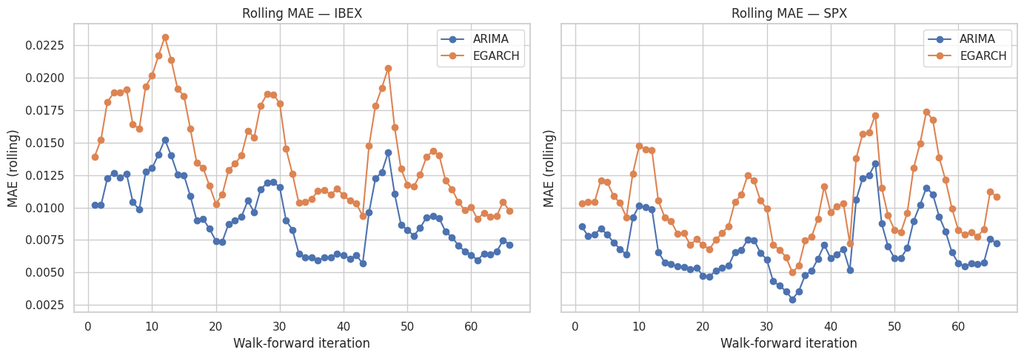

```
Saved: /home/apalo/projects/ibex-sp500-forecasting/figures/07_walkforward_stability/rolling_mae_arima_egarch.png
```

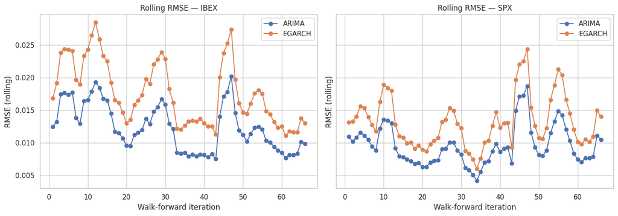

```
Saved: /home/apalo/projects/ibex-sp500-forecasting/figures/07_walkforward_stability/rolling_rmse_arima_egarch.png

Plotting high-error regimes (RMSE)...
```

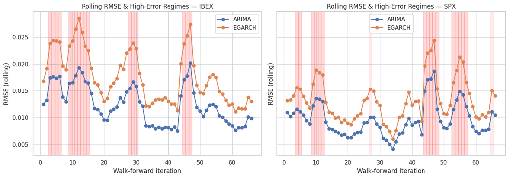

```
Saved: /home/apalo/projects/ibex-sp500-forecasting/figures/07_walkforward_stability/rolling_rmse_high_error_regimes.png

Plotting VaR coverage over time...
```

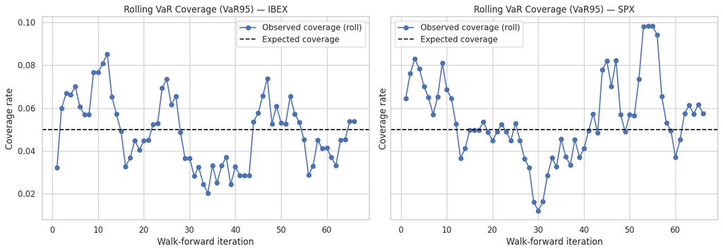

```
Saved: /home/apalo/projects/ibex-sp500-forecasting/figures/07_walkforward_stability/rolling_var_coverage.png

Plotting VaR coverage gap...
```

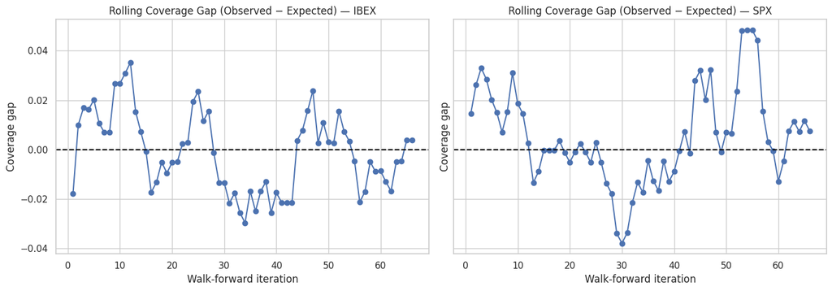

```
Saved: /home/apalo/projects/ibex-sp500-forecasting/figures/07_walkforward_stability/rolling_var_coverage_gap.png

Visualization summary:
• rolling_mae_arima_egarch.png        → Rolling MAE (ARIMA vs EGARCH, IBEX & SPX)
• rolling_rmse_arima_egarch.png       → Rolling RMSE (ARIMA vs EGARCH, IBEX & SPX)
• rolling_rmse_high_error_regimes.png → High-error regimes highlighted
• rolling_var_coverage.png            → Rolling VaR coverage vs 5% expected
• rolling_var_coverage_gap.png        → Gap (observed − expected) by iteration
```

```python
# STEP 6 VISUALIZATION: ERRORS & VAR COVERAGE

import pandas as pd
import numpy as np
import matplotlib.pyplot as plt
import seaborn as sns
from pathlib import Path

sns.set_theme(style="whitegrid")

# 6.0 Paths
PROJECT_ROOT = Path.home() / "projects" / "ibex-sp500-forecasting"
DATA_PATH    = PROJECT_ROOT / "data"
RESULTS_PATH = DATA_PATH / "results"
FIGURES_PATH = PROJECT_ROOT / "figures" / "07_walkforward_stability"

FIGURES_PATH.mkdir(parents=True, exist_ok=True)

print("Paths for figures:")
print("—", FIGURES_PATH)

# 6.1 Load evaluation datasets (Steps 3 & 4)
errors_file = RESULTS_PATH / "walkforward_errors.csv"
summary_file = RESULTS_PATH / "walkforward_errors_summary.csv"
var_file = RESULTS_PATH / "walkforward_var_coverage.csv"

print("\nLoading evaluation data...")

if not errors_file.exists():
    raise FileNotFoundError(errors_file)
if not var_file.exists():
    raise FileNotFoundError(var_file)

errors_df  = pd.read_csv(errors_file, parse_dates=["train_start","train_end","test_end"])
summary_df = pd.read_csv(summary_file) if summary_file.exists() else None
var_df     = pd.read_csv(var_file)

print("Errors DF:", errors_df.shape)
print("VaR DF   :", var_df.shape)

# 6.2 Rolling MAE / RMSE plots (ARIMA vs EGARCH)
print("\nPlotting rolling MAE / RMSE...")

models = errors_df["model"].unique()
indices = errors_df["index"].unique()

# MAE rolling
fig, axes = plt.subplots(1, 2, figsize=(14, 5), sharey=True)
for ax, idx in zip(axes, indices):
    sub = errors_df[errors_df["index"] == idx].copy()
    for m in models:
        g = sub[sub["model"] == m]
        ax.plot(g["iteration"], g["mae_roll"], marker="o", linestyle="-", label=m)
    ax.set_title(f"Rolling MAE — {idx}")
    ax.set_xlabel("Walk-forward iteration")
    ax.set_ylabel("MAE (rolling)")
    ax.grid(True)
    ax.legend()

plt.tight_layout()
mae_fig_path = FIGURES_PATH / "rolling_mae_arima_egarch.png"
plt.savefig(mae_fig_path, dpi=300)
plt.show()

print("Saved:", mae_fig_path)

# --- RMSE rolling ---
fig, axes = plt.subplots(1, 2, figsize=(14, 5), sharey=True)
for ax, idx in zip(axes, indices):
    sub = errors_df[errors_df["index"] == idx].copy()
    for m in models:
        g = sub[sub["model"] == m]
        ax.plot(g["iteration"], g["rmse_roll"], marker="o", linestyle="-", label=m)
    ax.set_title(f"Rolling RMSE — {idx}")
    ax.set_xlabel("Walk-forward iteration")
    ax.set_ylabel("RMSE (rolling)")
    ax.grid(True)
    ax.legend()

plt.tight_layout()
rmse_fig_path = FIGURES_PATH / "rolling_rmse_arima_egarch.png"
plt.savefig(rmse_fig_path, dpi=300)
plt.show()

print("Saved:", rmse_fig_path)

# 6.3 Highlight high-error regimes (sombras)
print("\nPlotting high-error regimes (RMSE)...")

fig, axes = plt.subplots(1, 2, figsize=(14, 5), sharey=True)
for ax, idx in zip(axes, indices):
    sub = errors_df[errors_df["index"] == idx].copy()
    for m in models:
        g = sub[sub["model"] == m]
        ax.plot(g["iteration"], g["rmse_roll"], marker="o", linestyle="-", label=m)

    high_reg = sub[sub["high_error_regime"] == 1]
    for it in high_reg["iteration"]:
        ax.axvspan(it - 0.5, it + 0.5, color="red", alpha=0.08)

    ax.set_title(f"Rolling RMSE & High-Error Regimes — {idx}")
    ax.set_xlabel("Walk-forward iteration")
    ax.set_ylabel("RMSE (rolling)")
    ax.grid(True)
    ax.legend()

plt.tight_layout()
regime_fig_path = FIGURES_PATH / "rolling_rmse_high_error_regimes.png"
plt.savefig(regime_fig_path, dpi=300)
plt.show()

print("Saved:", regime_fig_path)

# 6.4 VaR coverage plots (rolling coverage vs expected)
print("\nPlotting VaR coverage over time...")

fig, axes = plt.subplots(1, 2, figsize=(14, 5), sharey=True)
for ax, idx in zip(axes, indices):
    sub = var_df[var_df["index"] == idx].copy()
    ax.plot(sub["iteration"], sub["coverage_roll"], marker="o", linestyle="-", label="Observed coverage (roll)")
    ax.axhline(sub["expected_coverage"].iloc[0], color="black", linestyle="--", label="Expected coverage")
    ax.set_title(f"Rolling VaR Coverage (VaR95) — {idx}")
    ax.set_xlabel("Walk-forward iteration")
    ax.set_ylabel("Coverage rate")
    ax.grid(True)
    ax.legend()

plt.tight_layout()
var_cov_fig_path = FIGURES_PATH / "rolling_var_coverage.png"
plt.savefig(var_cov_fig_path, dpi=300)
plt.show()

print("Saved:", var_cov_fig_path)

# 6.5 VaR coverage gap plot (desviación respecto al 5 %)
print("\nPlotting VaR coverage gap...")

fig, axes = plt.subplots(1, 2, figsize=(14, 5), sharey=True)
for ax, idx in zip(axes, indices):
    sub = var_df[var_df["index"] == idx].copy()
    ax.plot(sub["iteration"], sub["coverage_gap"], marker="o", linestyle="-")
    ax.axhline(0.0, color="black", linestyle="--")
    ax.set_title(f"Rolling Coverage Gap (Observed − Expected) — {idx}")
    ax.set_xlabel("Walk-forward iteration")
    ax.set_ylabel("Coverage gap")
    ax.grid(True)

plt.tight_layout()
var_gap_fig_path = FIGURES_PATH / "rolling_var_coverage_gap.png"
plt.savefig(var_gap_fig_path, dpi=300)
plt.show()

print("Saved:", var_gap_fig_path)

# 6.6 Quick visual summary in text
print("\nVisualization summary:")
print("• rolling_mae_arima_egarch.png        → Rolling MAE (ARIMA vs EGARCH, IBEX & SPX)")
print("• rolling_rmse_arima_egarch.png       → Rolling RMSE (ARIMA vs EGARCH, IBEX & SPX)")
print("• rolling_rmse_high_error_regimes.png → High-error regimes highlighted")
print("• rolling_var_coverage.png            → Rolling VaR coverage vs 5% expected")
print("• rolling_var_coverage_gap.png        → Gap (observed − expected) by iteration")
```

## STEP 7 Analytical Summary

This notebook provides a comprehensive validation of the forecasting framework developed in earlier modules by examining its behaviour under a walk-forward evaluation.  
Unlike static backtests, this approach reveals how ARIMA and EGARCH respond to changing market regimes, structural shocks, and long-term drift, offering a true assessment of model robustness.

### 7.1 Out-of-Sample Error Dynamics (MAE & RMSE)

**Conclusion:**  
There is no evidence of long-term deterioration, parameter drift, or increasing instability in either model.

### 7.2 High-Error Regimes

**Interpretation:**  
Forecasting difficulty rises sharply during systemic stress but never becomes persistent or structural.  
Models return to normal behaviour as volatility subsides.

### 7.3 Dynamic VaR Coverage (VaR95)

This demonstrates that EGARCH provides a reasonably well-calibrated tail-risk signal, even when subjected to continuous re-estimation.

### 7.4 Structural Stability: CUSUM & CUSUMSQ

These diagnostics confirm that both models are structurally stable across the entire horizon.

### 7.5 Why the Chow Test Was Not Used

A classical Chow breakpoint test was considered but ultimately excluded because:

- walk-forward windows overlap (violating Chow assumptions)
- rolling errors are autocorrelated and heteroskedastic
- the test is designed for a single fixed breakpoint, not 66 overlapping re-estimations
- preliminary outputs produced systematic false positives, reflecting methodological misalignment rather than real breaks

### 7.6 Limitations and Future Extensions

- Window sizes are fixed; adaptive or volatility-based windows may offer improvements.
- EGARCH’s higher error reflects volatility sensitivity, not model failure.
- Macro-factors and liquidity indicators could enrich the forecasting environment.
- Regime-switching or hybrid (ARIMA–EGARCH blend) models may enhance performance.
- FRTB-aligned stress period selection could be integrated.

### 7.7 Executive Conclusion

Across the market history, including multiple crises, RIMA and EGARCH demonstrate:

- **no structural degradation**
- **no drift in forecasting errors**
- **no variance explosion or permanent instability**
- **adequate tail-risk calibration**
- **performance fully consistent with financial theory**

ARIMA acts as a robust, predictable benchmark, while EGARCH responds sharply—but appropriately—to volatility shocks without losing stability.

Overall, the entire modelling pipeline shows temporal robustness, interpretability, and resilience, making it suitable as a foundational forecasting and risk-assessment framework.

```python
# STEP 8 — POWER BI EXPORT

import sys
from pathlib import Path
import pandas as pd

# 1. Fix Python path for importing export() from src/
PROJECT_ROOT = Path.cwd().parent
SRC_DIR = PROJECT_ROOT / "src"

if str(PROJECT_ROOT) not in sys.path:
    sys.path.append(str(PROJECT_ROOT))

if str(SRC_DIR) not in sys.path:
    sys.path.append(str(SRC_DIR))

from src.export import export   # función que guarda en Desktop/forescasting_results

print("Preparing final exports for Power BI...")


# 8.1 Rolling errors (MAE/RMSE per iteration)
export(errors_df, "walkforward_errors")
print("✓ walkforward_errors.csv exported")


# 8.2 Rolling VaR coverage
export(var_df, "walkforward_var_coverage")
print("✓ walkforward_var_coverage.csv exported")


# 8.3 Stability diagnostics (CUSUM, CUSUMSQ)
export(wf_stab, "walkforward_errors_stability")
print("✓ walkforward_errors_stability.csv exported")


print("\nAll saved to Windows folder: str(EXPORTS_DIR / 'windows_path.csv')")
```

[output not shown]